# Chapter 13 - Correlations and clusters

## Plots of clusters

Finally, we create plots for each cluster. We start by fixing some plotting parameters for the bar plots that will be generated.

```r
## Set bar width:

xfac <- 0.15
rast_fac <- 0.05
```

Next, we define the function that will create all barplots per cluster, which also uses the get_means() helper function.

```r
## Function for extracting means per class:

get_means <- function(df, class) {
  df <- filter(df, Classes == class)
    df <- dplyr::select(df, VisualStrengthMean:ModalityExclusivity)
    return(apply(df, 2, mean))
    }

## Function for plotting modality norms and exclusivity:

plot_class <- function(df, class,
                       number, name, single = TRUE) {
  xmeans <- get_means(df, class)

    if (single) {
        quartz('', 9, 7.5)
        par(mai = c(2.5, 1.75, 1.75, 1))
        }

    if (single) {
        plot(1, 1,
             type = 'n', xaxt = 'n', yaxt = 'n',
             xlab = '', ylab = '', bty = 'n',
             xlim = c(1, 6), ylim = c(0, 5))
      } else {
        plot(1, 1,
             type = 'n', xaxt = 'n', yaxt = 'n',
             xlab = '', ylab = '', bty = 'n',
             xlim = c(1, 6), ylim = c(0, 6))
            }
    axis(side = 2, at = seq(0, 5, 1), las = 2,
            font = 2, lwd = 2, lwd.ticks = 2, cex.axis = 1.5)
    if (single) { mtext('Rating', side = 2,
                        line = 3.7, font = 2, cex = 2.5) }
    if (single) {
    mtext(str_c('Cluster ', number, ', ', '"', name, '"'),
          side = 3, line = 1.3, font = 2, cex = 2.05)
    mtext(str_c(round(xmeans[6] * 100), '% exclusive, N = ',
                nrow(filter(df, Classes == class))),
          side = 3, line = -0.45, font = 2, cex = 1.5)
        } else {
        mtext(str_c('Cluster ', number, ', ', '"', name, '"'),
              side = 3, line = 1.3, font = 2, cex = 1.75)
        mtext(str_c(round(xmeans[6] * 100), '% exclusive, N = ',
                    nrow(filter(df, Classes == class))),
              side = 3, line = -0.45, font = 2, cex = 1.35)
        }

    for (i in 1:5) {
        rect(xleft = i + xfac, xright = i + 1 - xfac,
             ybottom = 0, ytop = xmeans[i],
             col = mycols[i], lwd = 2)
        rasterImage(get(sense_names[i]),
                    xleft = i + xfac + rast_fac,
                    xright = i + 1 - xfac - rast_fac,
                    ybottom = -1.17 + rast_fac * 1.3,
                    ytop = -0.1 - rast_fac * 1.3, xpd = NA)
        }

    if (single) {
      text('Examples:', font = 2, cex = 1.8,
           x = 0.55, y = -1.85, xpd = NA)} else {
             text('Examples:', font = 2, cex = 1.8,
                  x = 0.55, y = -1.85 - 1, xpd = NA)
            }
    this_lab1 <- str_c(get_words(lyn, class, 10)[1:5],
                       collapse = ', ')
    this_lab2 <- str_c(get_words(lyn, class, 10)[6:10],
                       collapse = ', ')
    this_lab <- str_c(this_lab1, ', \n', this_lab2)
    if (single) {
    text(x = 1.2, y = -1.9, xpd = NA,
        labels = this_lab,
        font = 4, cex = 1.25, adj = 0, pos = 4)
        } else {
            text(x = -0.75, y = -3 - 1.2, xpd = NA,
                labels = this_lab,
                font = 4, cex = 1.15, pos = 4)
            }
    }
```

Finally, we create the individual plots.

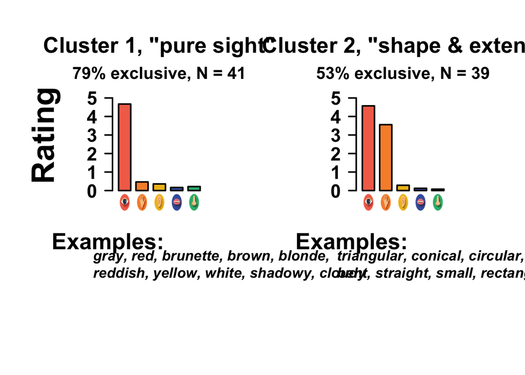

```r
## Plot 1 (double), 'pure sight words' + 'shape & extent':

quartz('', 11, 6)
par(mfrow = c(1, 2), mai = c(1.9, 1.5, 1, 0.5), omi = c(0.5, 0, 0, 0.5))
plot_class(lyn, 8, number = 1, name = 'pure sight', single = F)
mtext('Rating', side = 2, line = 3.7, font = 2, cex = 2.5)
plot_class(lyn, 9, number = 2, name = 'shape & extent', single = F)
```

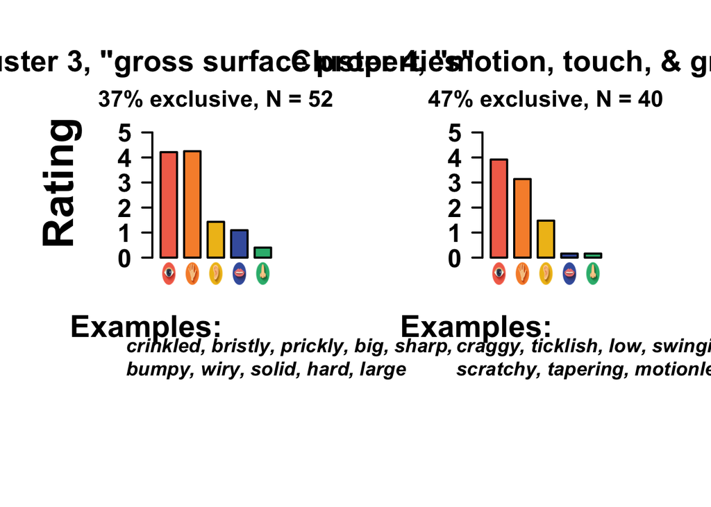

```r
## Double plot 2:

quartz('', 11, 6)
par(mfrow = c(1, 2), mai = c(1.9, 1.5, 1, 0.5), omi = c(0.5, 0, 0, 0.5))
plot_class(lyn, 12, number = 3, name = 'gross surface properties', single = F)
mtext('Rating', side = 2, line = 3.7, font = 2, cex = 2.5)
plot_class(lyn, 1, number = 4, name = 'motion, touch, & gravity', single = F)
```

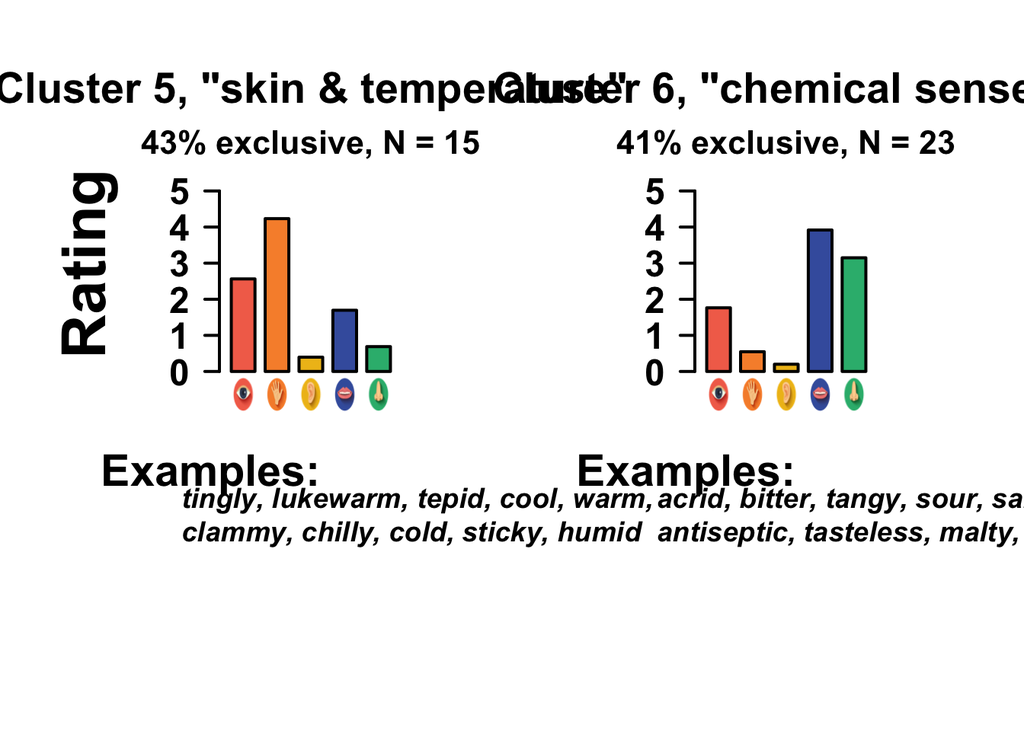

```r
## Plot 3:

quartz('', 11, 6)
par(mfrow = c(1, 2), mai = c(1.9, 1.5, 1, 0.5), omi = c(0.5, 0, 0, 0.5))
plot_class(lyn, 2, number = 5, name = 'skin & temperature', single = F)
mtext('Rating', side = 2, line = 3.7, font = 2, cex = 2.5)
plot_class(lyn, 3, number = 6, name = 'chemical senses', single = F)
```

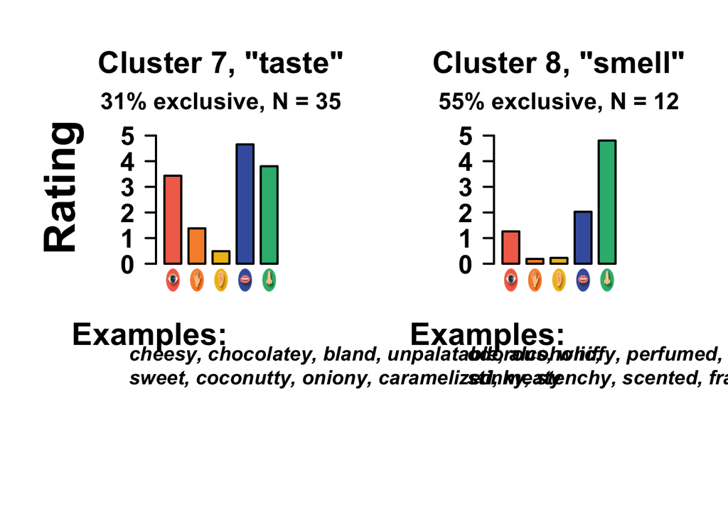

```r
## Plot 4 (double):

quartz('', 11, 6)
par(mfrow = c(1, 2), mai = c(1.9, 1.5, 1, 0.5), omi = c(0.5, 0, 0, 0.5))
plot_class(lyn, 6, number = 7, name = 'taste', single = F)
mtext('Rating', side = 2, line = 3.7, font = 2, cex = 2.5)
plot_class(lyn, 4, number = 8, name = 'smell', single = F)
```

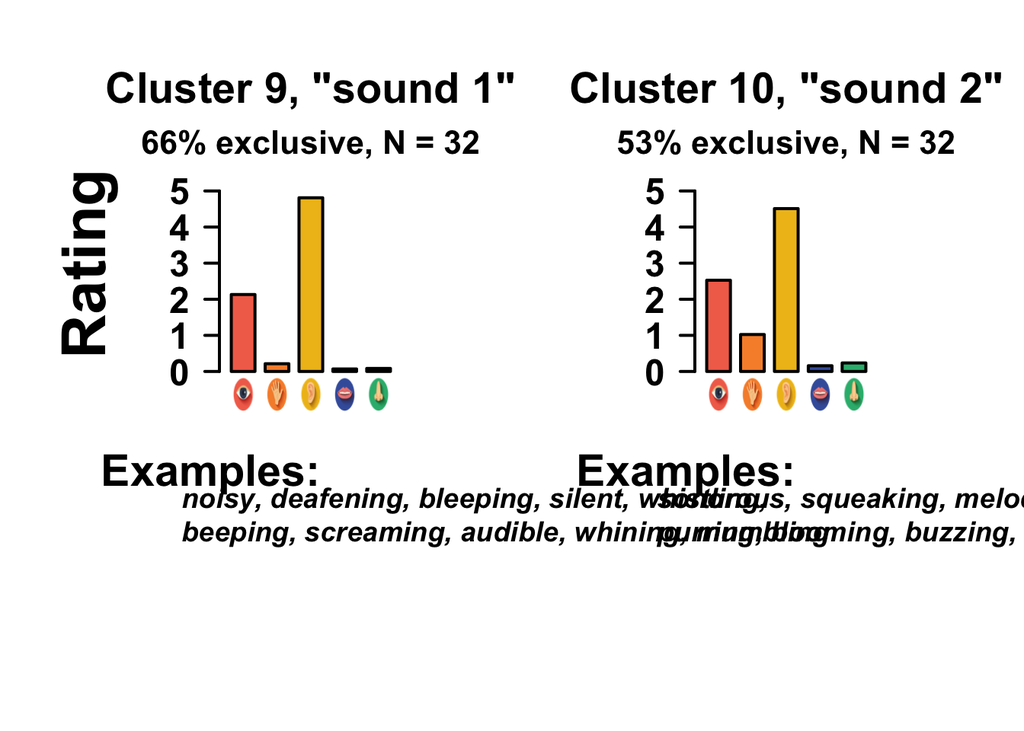

```r
## Plot 5 (double):

quartz('', 11, 6)
par(mfrow = c(1, 2), mai = c(1.9, 1.5, 1, 0.5), omi = c(0.5, 0, 0, 0.5))
plot_class(lyn, 10, number = 9, name = 'sound 1', single = F)
mtext('Rating', side = 2, line = 3.7, font = 2, cex = 2.5)
# axis(side = 2, at = seq(0, 5, 1), las = 2,
    # font = 2, lwd = 2, lwd.ticks = 2, cex.axis = 1.5)
plot_class(lyn, 11, number = 10, name = 'sound 2', single = F)
```

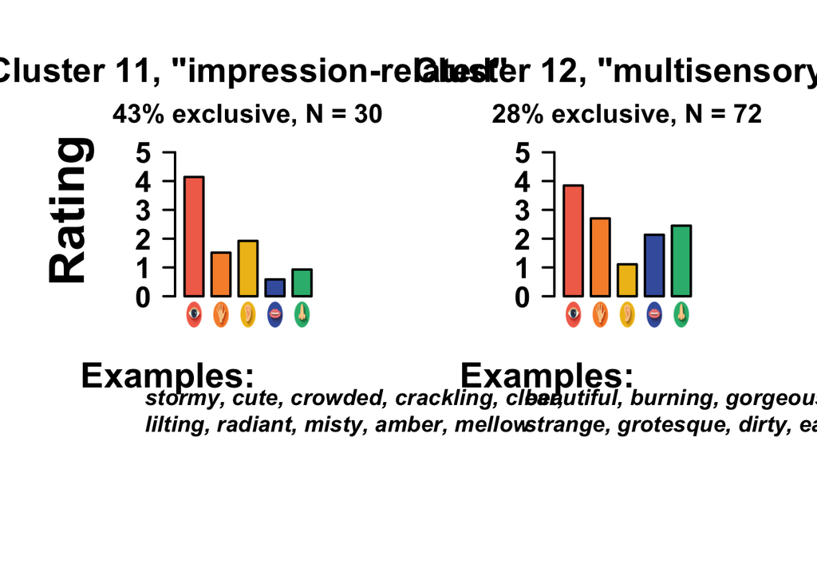

```r
## Plot 6 (double):

quartz('', 11, 6)
par(mfrow = c(1, 2), mai = c(1.9, 1.5, 1, 0.5), omi = c(0.5, 0, 0, 0.5))
plot_class(lyn, 7, number = 11, name = 'impression-related', single = F)
mtext('Rating', side = 2, line = 3.7, font = 2, cex = 2.5)
plot_class(lyn, 5, number = 12, name = 'multisensory', single = F)
```

## Save clusters into data frame

For the analyses in later chapters, we will need the clusters. So we extract them.

We’ll name the clusters for transparency.

```r
## Name the clusters:

lyn$Class <- lyn$Classes
lyn[lyn$Classes == 1, ]$Class <- 'motion & touch'
lyn[lyn$Classes == 2, ]$Class <- 'skin & temperature'
lyn[lyn$Classes == 3, ]$Class <- 'chemical senses'
lyn[lyn$Classes == 4, ]$Class <- 'smell'
lyn[lyn$Classes == 5, ]$Class <- 'multimodal'
lyn[lyn$Classes == 6, ]$Class <- 'taste'
lyn[lyn$Classes == 7, ]$Class <- 'impression-related'
lyn[lyn$Classes == 8, ]$Class <- 'pure sight'
lyn[lyn$Classes == 9, ]$Class <- 'shape & extent'
lyn[lyn$Classes == 10, ]$Class <- 'sound 1'
lyn[lyn$Classes == 11, ]$Class <- 'sound 2'
lyn[lyn$Classes == 12, ]$Class <- 'gross surface'
```

Next, we add all the relevant color and image information to the data frame.

```r
## Make color identifiers for the different classes:

lyn$Color <- mycols[1]  # vision
lyn[lyn$Classes == 2, ]$Color <- mycols[which.max(get_means(lyn, 2)[1:5])]
lyn[lyn$Classes == 3, ]$Color <- mycols[which.max(get_means(lyn, 3)[1:5])]
lyn[lyn$Classes == 4, ]$Color <- mycols[which.max(get_means(lyn, 4)[1:5])]
lyn[lyn$Classes == 5, ]$Color <- mycols[which.max(get_means(lyn, 5)[1:5])]
lyn[lyn$Classes == 6, ]$Color <- mycols[which.max(get_means(lyn, 6)[1:5])]
lyn[lyn$Classes == 7, ]$Color <- mycols[which.max(get_means(lyn, 7)[1:5])]
lyn[lyn$Classes == 8, ]$Color <- mycols[which.max(get_means(lyn, 8)[1:5])]
lyn[lyn$Classes == 9, ]$Color <- mycols[which.max(get_means(lyn, 9)[1:5])]
lyn[lyn$Classes == 10, ]$Color <- mycols[which.max(get_means(lyn, 10)[1:5])]
lyn[lyn$Classes == 11, ]$Color <- mycols[which.max(get_means(lyn, 11)[1:5])]
lyn[lyn$Classes == 12, ]$Color <- mycols[which.max(get_means(lyn, 12)[1:5])]

## Make image identifiers for the different classes:

lyn$Image <- 's1'
lyn[lyn$Classes == 2, ]$Image <- sense_names[which.max(get_means(lyn, 2)[1:5])]
lyn[lyn$Classes == 3, ]$Image <- sense_names[which.max(get_means(lyn, 3)[1:5])]
lyn[lyn$Classes == 4, ]$Image <- sense_names[which.max(get_means(lyn, 4)[1:5])]
lyn[lyn$Classes == 5, ]$Image <- sense_names[which.max(get_means(lyn, 5)[1:5])]
lyn[lyn$Classes == 6, ]$Image <- sense_names[which.max(get_means(lyn, 6)[1:5])]
lyn[lyn$Classes == 7, ]$Image <- sense_names[which.max(get_means(lyn, 7)[1:5])]
lyn[lyn$Classes == 8, ]$Image <- sense_names[which.max(get_means(lyn, 8)[1:5])]
lyn[lyn$Classes == 9, ]$Image <- sense_names[which.max(get_means(lyn, 9)[1:5])]
lyn[lyn$Classes == 10, ]$Image <- sense_names[which.max(get_means(lyn, 10)[1:5])]
lyn[lyn$Classes == 11, ]$Image <- sense_names[which.max(get_means(lyn, 11)[1:5])]
lyn[lyn$Classes == 12, ]$Image <- sense_names[which.max(get_means(lyn, 12)[1:5])]
```

Finally, we write this to a file.

```r
## Write to file:

write_csv(lyn, '../processed-data/lyn_cluster.csv')
```

## Assess the relative distance and variance for different models

First, let’s get categories for sight/touch and taste/smell.

```r
chem <- c('Gustatory', 'Olfactory')
touchy <- c('Visual', 'Haptic')
lyn <- mutate(lyn,
              LargeGroup = ifelse(DominantModality %in% chem,
                                  'chem', DominantModality),
              LargeGroup = ifelse(LargeGroup %in% touchy,
                                  'touchy', LargeGroup))
```

Next, let’s compute the variance within each group. For this, we need the cluster means.

```r
group3_means <- lyn %>%
  group_by(LargeGroup) %>%
  summarize(Vis = mean(VisualStrengthMean),
            Hap = mean(HapticStrengthMean),
            Aud = mean(AuditoryStrengthMean),
            Gus = mean(GustatoryStrengthMean),
            Olf = mean(OlfactoryStrengthMean))
group12_means <- lyn %>%
  group_by(Classes) %>%
  summarize(Vis = mean(VisualStrengthMean),
            Hap = mean(HapticStrengthMean),
            Aud = mean(AuditoryStrengthMean),
            Gus = mean(GustatoryStrengthMean),
            Olf = mean(OlfactoryStrengthMean))
group5_means <- lyn %>%
  group_by(DominantModality) %>%
  summarize(Vis = mean(VisualStrengthMean),
            Hap = mean(HapticStrengthMean),
            Aud = mean(AuditoryStrengthMean),
            Gus = mean(GustatoryStrengthMean),
            Olf = mean(OlfactoryStrengthMean))
```

Initialize empty columns to be filled with distance of each word to each cluster center:

```r
lyn$Class3_dist <- NA
lyn$Class5_dist <- NA
lyn$Class12_dist <- NA
```

Next, let’s compute the variance within each cluster. For this, we need to compute the Euclidian distance of each word to each cluster mean.

```r
for (i in 1:nrow(group3_means)) {
  # Get one of the three clusters:
  this_mod <- group3_means[i, ]

  # Extract values only:
  this_mod_vals <- unlist(this_mod[, 2:6])

  # Extract from the main data frame all words from that cluster:
  all_lyn <- filter(lyn, LargeGroup == this_mod$LargeGroup)

  # And only the values:
  all_lyn <- select(all_lyn, VisualStrengthMean:OlfactoryStrengthMean)

  # Initialize empty vector to be filled with distances:
  mydists <- rep(NA, nrow(all_lyn))

  # Loop through subset and compute distances to cluster mean:
  for (j in 1:nrow(all_lyn)) {
    mydists[j] <- dist(rbind(all_lyn[j, ], this_mod_vals))
  }

  lyn[lyn$LargeGroup == this_mod$LargeGroup, ]$Class3_dist <- mydists

}
```

Same for dominant modality:

```r
for (i in 1:nrow(group5_means)) {
  # Get one of the three clusters:
  this_mod <- group5_means[i, ]

  # Extract values only:
  this_mod_vals <- unlist(this_mod[, 2:6])

  # Extract from the main data frame all words from that cluster:
  all_lyn <- filter(lyn, DominantModality == this_mod$DominantModality)

  # And only the values:
  all_lyn <- select(all_lyn, VisualStrengthMean:OlfactoryStrengthMean)

  # Initialize empty vector to be filled with distances:
  mydists <- rep(NA, nrow(all_lyn))

  # Loop through subset and compute distances to cluster mean:
  for (j in 1:nrow(all_lyn)) {
    mydists[j] <- dist(rbind(all_lyn[j, ], this_mod_vals))
  }

  lyn[lyn$DominantModality == this_mod$DominantModality, ]$Class5_dist <- mydists

}
```

Same for 12 clusters:

```r
for (i in 1:nrow(group12_means)) {
  # Get one of the three clusters:
  this_mod <- group12_means[i, ]

  # Extract values only:
  this_mod_vals <- unlist(this_mod[, 2:6])

  # Extract from the main data frame all words from that cluster:
  all_lyn <- filter(lyn, Classes == this_mod$Classes)

  # And only the values:
  all_lyn <- select(all_lyn, VisualStrengthMean:OlfactoryStrengthMean)

  # Initialize empty vector to be filled with distances:
  mydists <- rep(NA, nrow(all_lyn))

  # Loop through subset and compute distances to cluster mean:
  for (j in 1:nrow(all_lyn)) {
    mydists[j] <- dist(rbind(all_lyn[j, ], this_mod_vals))
  }

  lyn[lyn$Classes == this_mod$Classes, ]$Class12_dist <- mydists

}
```

Check descriptive averages:

```r
lyn %>%
  group_by(LargeGroup) %>%
  summarize(SD = sd(Class3_dist))
```

```
## # A tibble: 3 x 2
##   LargeGroup    SD
##   <chr>      <dbl>
## 1 Auditory   0.593
## 2 chem       0.703
## 3 touchy     0.773
```

```r
lyn %>%
  group_by(DominantModality) %>%
  summarize(SD = sd(Class5_dist))
```

```
## # A tibble: 5 x 2
##   DominantModality    SD
##   <chr>            <dbl>
## 1 Auditory         0.593
## 2 Gustatory        0.626
## 3 Haptic           0.627
## 4 Olfactory        0.749
## 5 Visual           0.762
```

```r
lyn %>%
  group_by(Classes) %>%
  summarize(SD = sd(Class12_dist))
```

```
## # A tibble: 12 x 2
##    Classes    SD
##      <dbl> <dbl>
##  1       1 0.642
##  2       2 0.527
##  3       3 0.641
##  4       4 0.252
##  5       5 0.542
##  6       6 0.418
##  7       7 0.613
##  8       8 0.205
##  9       9 0.343
## 10      10 0.361
## 11      11 0.467
## 12      12 0.444
```

```r
# SD across all distances:
sd(lyn$Class3_dist)
```

```
## [1] 0.8349572
```

```r
sd(lyn$Class5_dist)
```

```
## [1] 0.7846297
```

```r
sd(lyn$Class12_dist)
```

```
## [1] 0.7291597
```

This completes the analyses presented in Chapter 13.